# Data Science e Laboratorio

**Gervasi Gioele**  
31 Agosto 2026  
A.A. 2025/2026

# Introduzione e Motivazioni

Cosa sono i DGA?

**Domande di ricerca:**

- Come riconosco un DGA da un dominio legittimo?
- Come evidenzio i pattern malevoli?
- Quali sono i limiti di questo approccio?

# Descrizione del Dataset

- **Fonte:** [DGA Detection Dataset](https://huggingface.co/datasets/harpomaxx/dga-detection) (Hugging Face).
- **Campionamento:** 30.000.
- **Famiglie malware identificate:** 35 (10,4% del campione DGA) — il restante 89,6% non riporta la famiglia di origine nel dataset sorgente.
- **Feature estratte per lo studio:**
  1. Lunghezza
  2. Entropia di Shannon
  3. Rapporto Vocali
  4. Rapporto Numeri

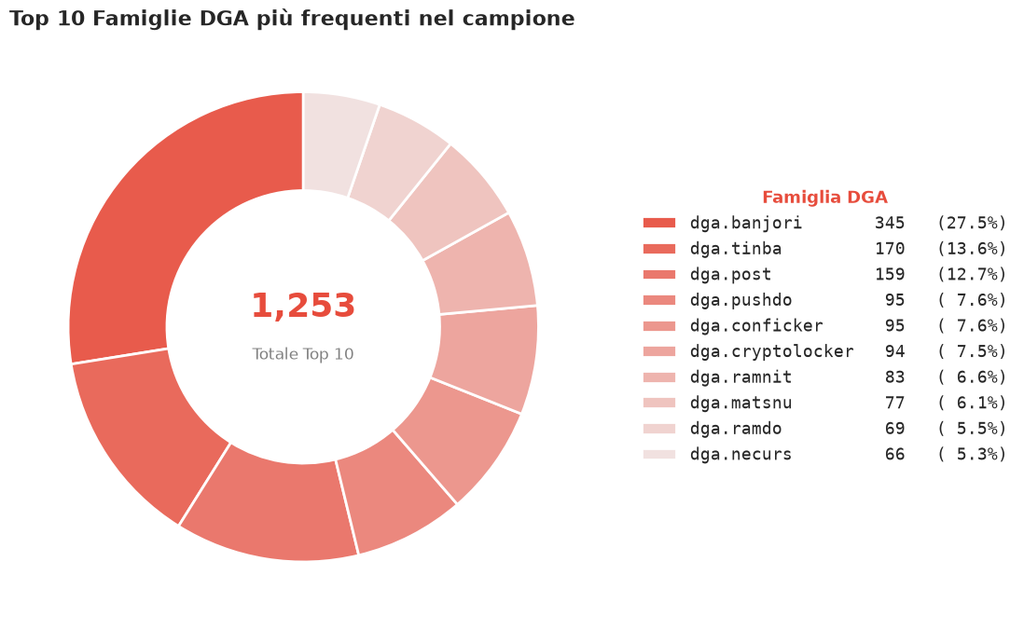

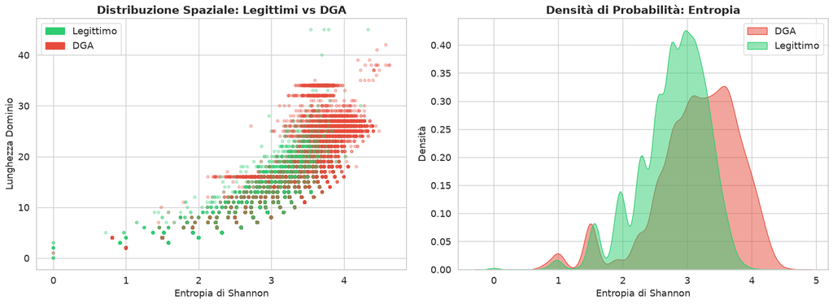

### L'ambiguità del dato grezzo

Esplorando visivamente la distribuzione delle feature, emerge subito la complessità del problema:

- **Sovrapposizione massiccia**.
- **Il paradosso dell'entropia:** sebbene i malware tendano ad avere un'entropia mediamente più alta, l'area di intersezione è molto vasta.

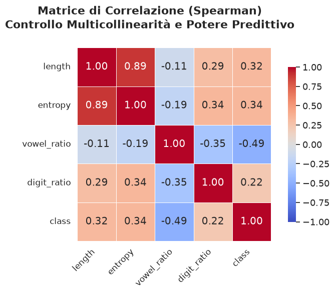

## 1. Approccio Non Supervisionato (Clustering DBSCAN)

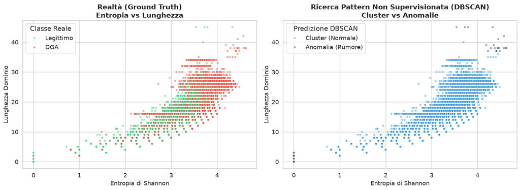

### Limiti dell'Approccio Non Supervisionato

- **Sovrapposizione Naturale:** Non esiste un confine netto tra le due classi.
- **Il Fallimento del DBSCAN:** Senza etichette, l'algoritmo ingloba i DGA nel traffico "Normale".
- **Necessità di ML Supervisionato**

## 2. Approccio Supervisionato (Random Forest)

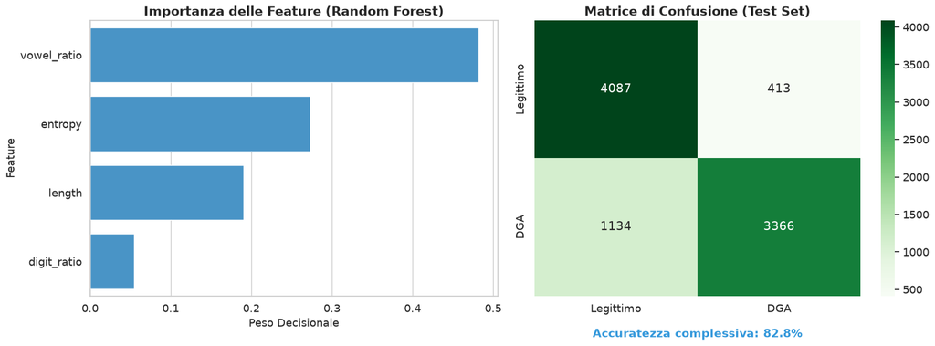

```
Analisi per famiglia basata su 476 domini con etichetta nota su 4500 DGA totali nel test set
```

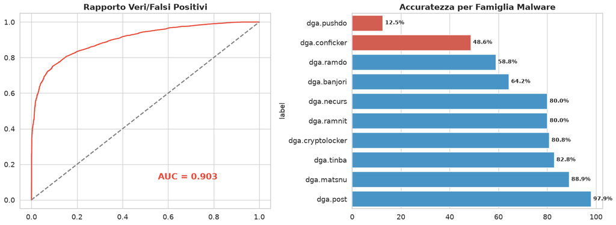

### Il Trade-off del Random Forest

- **Evoluzione:** Il *Rapporto Vocali* diventa la metrica chiave.
- **Filtro "Sicuro":** Pochi Falsi Positivi sui domini legittimi. Il modello preferisce lasciar passare un dubbio piuttosto che bloccare un sito vero.
- **Il Punto Cieco:** Crollo drastico su malware avanzati come *Pushdo* (12.5%).

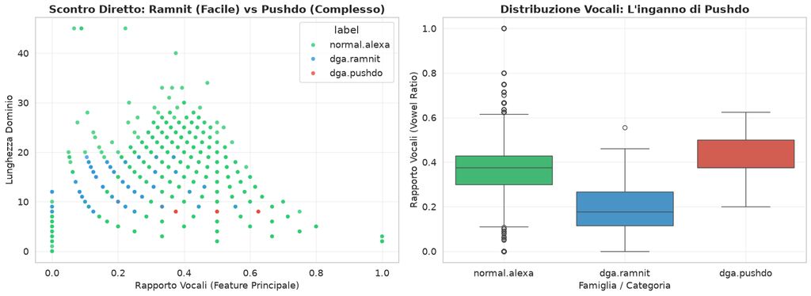

### L'inganno della "Pronunciabilità" (Pushdo)

- **Mimetizzazione Visiva:** *Pushdo* (rosso) si sovrappone perfettamente al traffico legittimo (verde).
- **La Tecnica:** *Pushdo* forza l'uso delle vocali per sembrare umano, allineando la sua mediana a quella reale.
- **Conclusione:** Contro algoritmi pseudo naturali servono analisi semantiche.

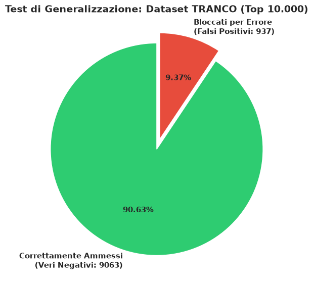

### Tenuta sul Traffico Reale (Test Tranco)

- **Generalizzazione (90.6%):** Il modello non ha fatto *overfitting*, riconosce correttamente la maggior parte del traffico moderno.
- **Il "Concept Drift" (9.3% FP):** Diventato severo sulle vocali, il modello blocca per errore domini legittimi.
- **Applicabilità:** Ideale come *Anomaly Detector*, non come blocco automatico.

# Conclusioni